# T-distribution

## Gosset

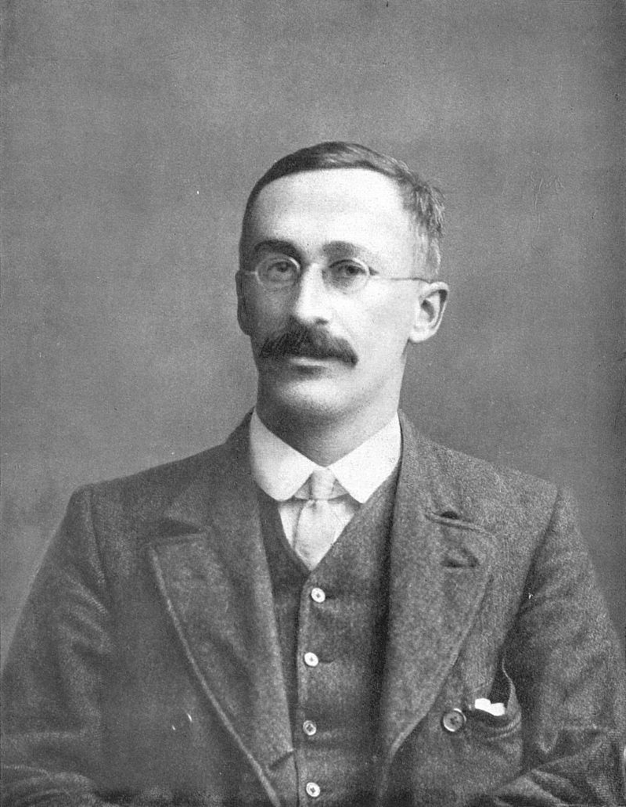

In probability and statistics, Student’s t-distribution (or simply the t-distribution) is any member of a family of continuous probability distributions that arises when estimating the mean of a normally distributed population in situations where the sample size is small and population standard deviation is unknown.

In the English-language literature it takes its name from William Sealy Gosset’s 1908 paper in Biometrika under the pseudonym “Student”. Gosset worked at the Guinness Brewery in Dublin, Ireland, and was interested in the problems of small samples, for example the chemical properties of barley where sample sizes might be as low as 3.

Source: [Wikipedia](https://en.wikipedia.org/wiki/Student%27s_t-distribution)

[figure not shown]

## Population distribution

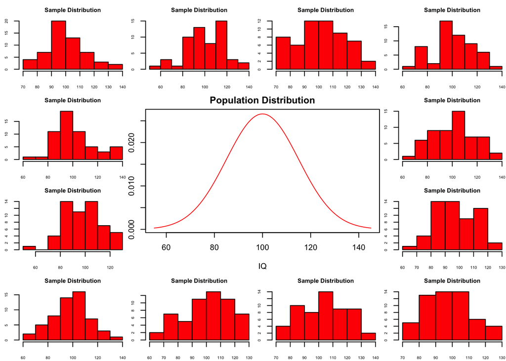

```r
layout(matrix(c(2:6,1,1,7:8,1,1,9:13), 4, 4))

n  = 56    # Sample size
df = n - 1 # Degrees of freedom

mu    = 100
sigma = 15

IQ = seq(mu-45, mu+45, 1)

par(mar=c(4,2,2,0))
plot(IQ, dnorm(IQ, mean = mu, sd = sigma), type='l', col="red", main = "Population Distribution")

n.samples = 12

for(i in 1:n.samples) {

  par(mar=c(2,2,2,0))
  hist(rnorm(n, mu, sigma), main="Sample Distribution", cex.axis=.5, col="red", cex.main = .75)

}
```

## T-statistic

$$T_{n-1} = \frac{\bar{x}-\mu}{SE_x} = \frac{\bar{x}-\mu}{s_x / \sqrt{n}}$$

So the t-statistic represents the deviation of the sample mean $\bar{x}$ from the population mean $\mu$, considering the sample size, expressed as the degrees of freedom $df = n - 1$

## A sample

Let’s take one sample from our normal populatiion and calculate the t-value.

```r
x = rnorm(n, mu, sigma); x
```

```
##  [1]  84.16590 105.80573  84.21034 121.23724 112.42107  99.57765  90.41021
##  [8]  99.58665 119.64132  97.01425  89.00519 109.34631  89.93511 103.83887
## [15]  85.87705  90.35990  99.76446  85.64888  91.71741 112.47148  96.56749
## [22]  79.45547 111.05584 103.06981 108.84445 113.04924  95.48842 126.25923
## [29] 118.64267 132.57172 124.63125  95.61023 110.03980  84.10788  87.94107
## [36] 110.31645  96.73329  97.73969 113.27512  87.45019 117.66183 101.55392
## [43]  96.39643  89.39756  94.75534 102.70141  84.84853  86.74214  97.12350
## [50]  93.22684 106.51012  94.09187 110.74337 111.71131 100.31925  88.79552
```

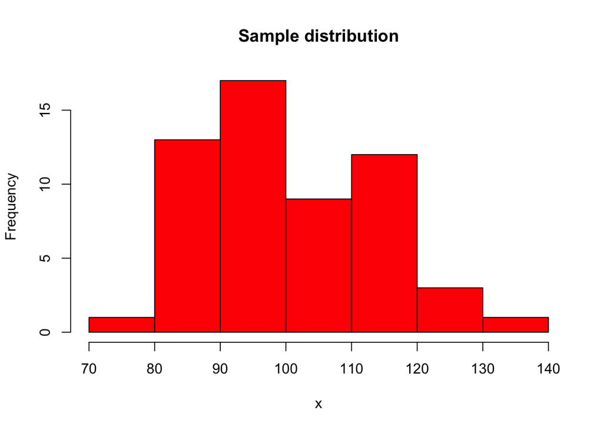

```r
hist(x, main = "Sample distribution", col = "red")
```

```r
mean(x)
```

```
## [1] 100.7404
```

## t-value

$$T_{n-1} = \frac{\bar{x}-\mu}{SE_x} = \frac{\bar{x}-\mu}{s_x / \sqrt{n}}$$

```r
t = (mean(x) - mu) / (sd(x) / sqrt(n)); t
```

```
## [1] 0.444529
```

## More samples

let’s take more samples.

```r
n.samples     = 1000
mean.x.values = vector()
se.x.values   = vector()

for(i in 1:n.samples) {
  x = rnorm(n, mu, sigma)
  mean.x.values[i] = mean(x)
  se.x.values[i]   = (sd(x) / sqrt(n))
}
```

## Mean and SE for all samples

```r
head(cbind(mean.x.values, se.x.values))
```

```
##      mean.x.values se.x.values
## [1,]     101.15070    1.926684
## [2,]     103.39825    1.416016
## [3,]     100.83757    1.935314
## [4,]      98.91465    2.171209
## [5,]     103.26691    1.956369
## [6,]      98.77354    1.742722
```

## Samples distribution

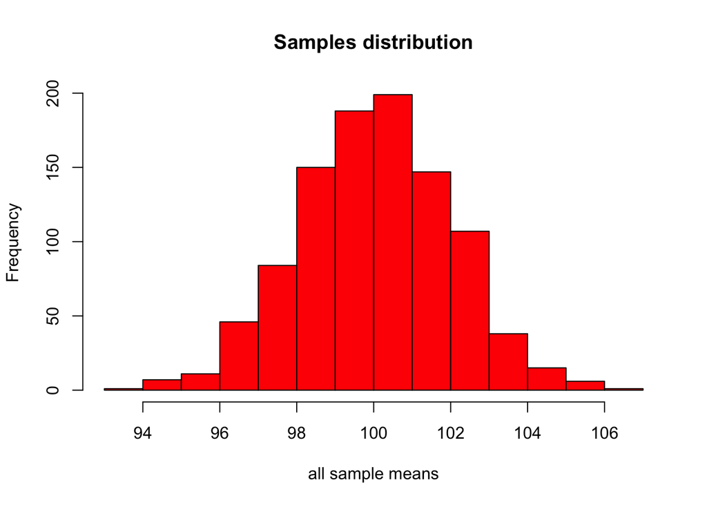

```r
hist(mean.x.values,
     col  = "red",
     main = "Samples distribution",
     xlab = "all sample means")
```

## Calculate t-values

$$T_{n-1} = \frac{\bar{x}-\mu}{SE_x} = \frac{\bar{x}-\mu}{s_x / \sqrt{n}}$$

```r
t.values = (mean.x.values - mu) / se.x.values

tail(cbind(mean.x.values, mu, se.x.values, t.values))
```

```
##         mean.x.values  mu se.x.values   t.values
##  [995,]     100.90254 100    1.943109  0.4644801
##  [996,]     103.15210 100    2.044551  1.5417063
##  [997,]      99.11595 100    2.322835 -0.3805906
##  [998,]     102.46388 100    2.154463  1.1436153
##  [999,]     100.95556 100    2.121274  0.4504672
## [1000,]     100.51442 100    2.008699  0.2560980
```

## Sampled t-values

What is the distribution of all these t-values?

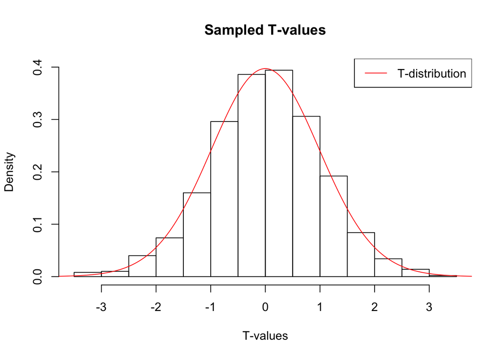

```r
hist(t.values,
     freq = F,
     main = "Sampled T-values",
     xlab = "T-values",
     ylim = c(0, .4))
T = seq(-4, 4, .01)
lines(T, dt(T,df), col = "red")
legend("topright", lty = 1, col="red", legend = "T-distribution")
```

## T-distribution

So if the population is normaly distributed (assumption of normality) the t-distribution represents the deviation of sample means from the population mean ($\mu$), given a certain sample size ($df = n - 1$).

The t-distibution therefore is different for different sample sizes and converges to a standard normal distribution if sample size is large enough.

The t-distribution is defined by:

$$\textstyle\frac{\Gamma \left(\frac{\nu+1}{2} \right)} {\sqrt{\nu\pi}\,\Gamma \left(\frac{\nu}{2} \right)} \left(1+\frac{x^2}{\nu} \right)^{-\frac{\nu+1}{2}}\!$$

where $\nu$ is the number of degrees of freedom and $\Gamma$ is the gamma function.

Source: [wikipedia](https://en.wikipedia.org/wiki/Student%27s_t-distribution)

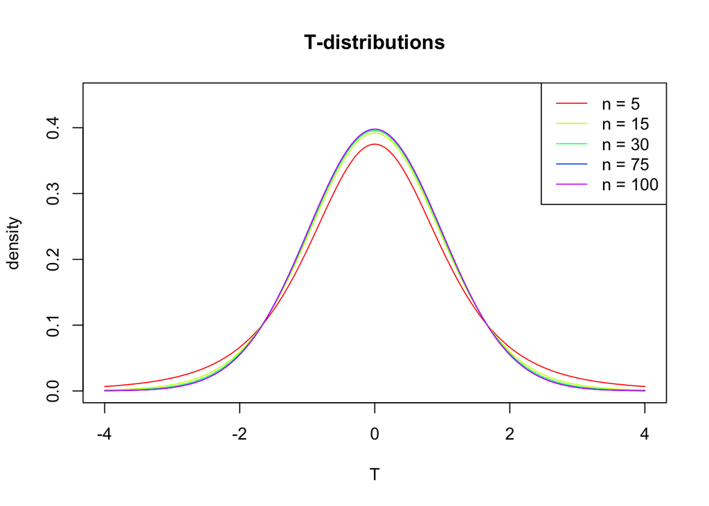

## One or two sided

Two sided

- $H_A: \bar{x} \neq \mu$

One sided

- $H_A: \bar{x} > \mu$
- $H_A: \bar{x} < \mu$

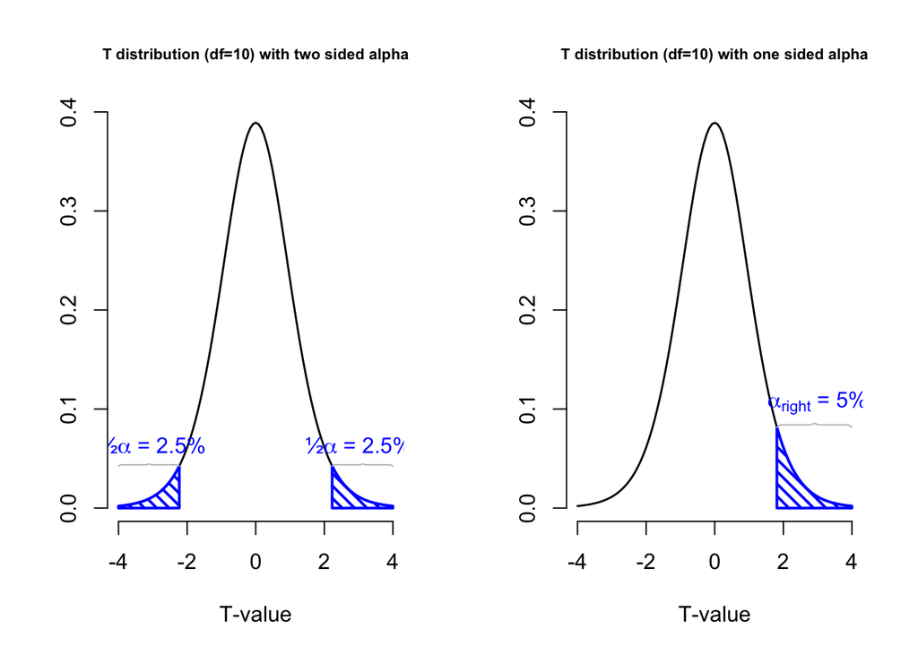

## Effect-size

The effect-size is the standardised difference between the mean and the expected $\mu$. In the t-test effect-size is expressed as $r$.

$$r = \sqrt{\frac{t^2}{t^2 + \text{df}}}$$

```r
r = sqrt(t^2/(t^2 + df))

r
```

[output not shown]

## Effect-size distribution

We can also calculate effect-sizes for all our calculated t-values. Under the assumption of $H_0$ the effect-size distribution looks like this.

```r
r = sqrt(t.values^2/(t.values^2 + df))

tail(cbind(mean.x.values, mu, se.x.values, t.values, r))
```

```
##         mean.x.values  mu se.x.values   t.values          r
##  [995,]     100.90254 100    1.943109  0.4644801 0.06250800
##  [996,]     103.15210 100    2.044551  1.5417063 0.20353227
##  [997,]      99.11595 100    2.322835 -0.3805906 0.05125138
##  [998,]     102.46388 100    2.154463  1.1436153 0.15240368
##  [999,]     100.95556 100    2.121274  0.4504672 0.06062925
## [1000,]     100.51442 100    2.008699  0.2560980 0.03451168
```

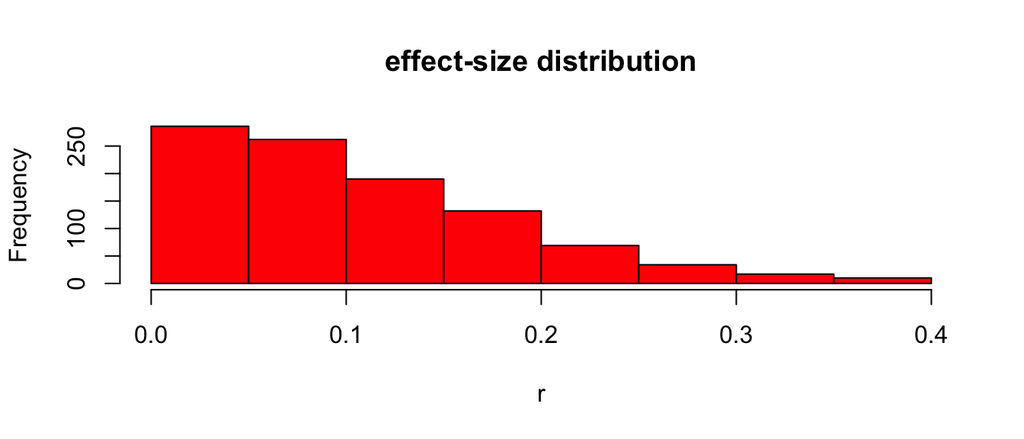

```r
hist(r, main = "effect-size distribution", col = "red")
```

Cohen (1988)

- Small: 0 <= .1
- Medium: .1 <= .3
- Large: .3 <= .5

## Power

- Strive for 80%
- Based on know effect size
- Calculate number of subjects needed
- Use [G*Power](http://www.gpower.hhu.de) to calculate

## Alpha Power

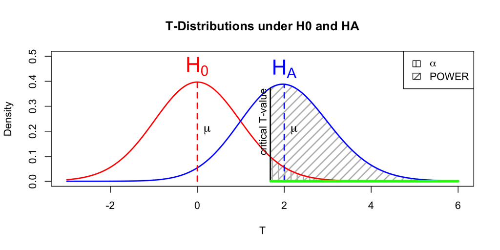

[interactive chart not shown]

```r
T = seq(-3,6,.01)
N = 45
E = 2

# Set plot
plot(0,0,
     type = "n",
     ylab = "Density",
     xlab = "T",
     ylim = c(0,.5),
     xlim = c(-3,6),
     main = "T-Distributions under H0 and HA")

critical_t = qt(.05,N-1,lower.tail=FALSE)

# Alpha
range_x = seq(critical_t,6,.01)
polygon(c(range_x,rev(range_x)),
        c(range_x*0,rev(dt(range_x,N-1,ncp=0))),
        col     = "grey",
        density = 10,
        angle   = 90,
        lwd     = 2)

# Power
range_x = seq(critical_t,6,.01)
polygon(c(range_x,rev(range_x)),
        c(range_x*0,rev(dt(range_x,N-1,ncp=E))),
        col     = "grey",
        density = 10,
        angle   = 45,
        lwd     = 2)

lines(T,dt(T,N-1,ncp=0),col="red", lwd=2) # H0 line
lines(T,dt(T,N-1,ncp=E),col="blue",lwd=2) # HA line

# Critical value
lines(rep(critical_t,2),c(0,dt(critical_t,N-1,ncp=E)),lwd=2,col="black")
text(critical_t,dt(critical_t,N-1,ncp=E),"critical T-value",pos=2, srt = 90)

# H0 and HA
text(0,dt(0,N-1,ncp=0),expression(H[0]),pos=3,col="red", cex=2)
text(E,dt(E,N-1,ncp=E),expression(H[A]),pos=3,col="blue",cex=2)

# Mu H0 line
lines(c(0,0),c(0,dt(0,N-1)), col="red",  lwd=2,lty=2)
text(0,dt(0,N-1,ncp=0)/2,expression(mu),pos=4,cex=1.2)
# Mu HA line
lines(c(E,E),c(0,dt(E,N-1,ncp=E)),col="blue",lwd=2,lty=2)
text(E,dt(0,N-1,ncp=0)/2,expression(paste(mu)),pos=4,cex=1.2)

# t-value
lines( c(critical_t+.01,6),c(0,0),col="green",lwd=4)

# Legend
legend("topright", c(expression(alpha),'POWER'),density=c(10,10),angle=c(90,45))
```